# Experimental Sociology - Week 5

Evolutionary ABMs: Basics

Published

2025-03-21

# 🤖 **Evolutionary ABMs: Basics**

Welcome back! Last week we learned how to **set up a simple agent-based model (ABM)**. Today we take the next step and **embed evolutionary dynamics** into that ABM. Our running example is the well-known Prisoner’s Dilemma (PD) tournament studied by Axelrod (1980).

## 🎯 Learning Goals

By the end of this chapter, you will be able to:

1. **Explain** the three ingredients of an evolutionary process in repeated games.
2. **Design** an ABM that lets agents play repeated game.
3. **Implement** selection and mutation to evolve strategies over time.
4. **Interpret** simulation output and relate it to results from evolutionary game theory.

# 🤖 **Evolutionary ABMs**

We will use the hole infrastructure we build last time! That is we will use all the files, but modify them in a given way, at the end of the chapter you can download the entire code.

Remember what we need for an evolutionary process:

- Repeated interaction
- Learning due to fitness
- Random mutation

## Repeated Interaction

We start with repeated interactions. First, we must define what a **single interaction** looks like. In the Prisoner’s Dilemma, the fitness values for a single encounter are typically defined like this:

Table 1: Fitness function for a single interaction in the Prisoner’s Dilemma

|  | Cooperate | Defect |
| --- | --- | --- |
| **Cooperate** | $b-c$ | $-c$ |
| **Defect** | $\underline{b}$ | $0$ |

If the opponent cooperates, the agent receives a benefit $b$; if the agent chooses to cooperate, they pay a cost $c$.

We assume that each agent has a specific strategy. Agents interact with all other agents multiple times. At the end of these repeated interactions, we evaluate which strategy performs best in terms of **total fitness**.

To set up the model, we need to define:

- How many agents we have
- What strategies they can adopt
- How often each pair of agents interacts

Let’s examine these in turn.

### Number of Agents

The number of agents ($n$) is somewhat flexible. It needs to be large enough to ensure a meaningful population and to allow a sufficient diversity of strategies. More on that shortly.

### Strategy Space

In repeated games, the number of potential strategies is infinite. Clearly, we cannot include all possible strategies in our simulation. This is where **you**, the modeler, must decide which strategies or families of strategies to implement. These choices will directly affect the outcome of what can be achieved and explained by your model.

To simplify, let’s assume that agents can remember only a limited amount of past interactions. This is called their **memory**. If memory is set to 0, agents cannot remember anything; their strategy is simply to **always cooperate (aC)** or **always defect (aD)**. If we allow for probabilistic behavior, each agent could also have a cooperation probability $p \in [0, 1]$, but to keep things simple, we will restrict our model to pure strategies only.

Now let’s consider **memory = 1**. Each agent remembers only the outcome of the **last round**. Since each interaction outcome can be one of four possibilities — (C, C), (C, D), (D, C), and (D, D) — a memory-1 strategy must specify what to do in response to each of those, plus what to do in the **first round**, when there is no history.

Hence, the total number of possible strategies is:

- $2$ choices for the first move (C or D)
- $2^4 = 16$ choices for how to respond to each of the four remembered outcomes

Which gives us: $2 \times 2^4 = 32$ possible strategies.

### Number of Rounds

Before we define how many times each pair of agents interacts, we need to make a design decision:

> Should all agent pairs interact for the same number of rounds?

If we allow a **random number of rounds per agent pair**, we introduce a degree of realism — but also random variability that can obscure the impact of strategic differences. This makes the results harder to interpret. One way to mitigate this would be to run many replications, relying on the law of large numbers to average out randomness. However, doing so would significantly increase computational demands and, in the end, likely lead to the same conclusions we’d reach by using a simpler setup, namely that **all agent pairs play the same number of rounds**. Therefore we will use the later procedure.

However, evolutionary game theory tells us that many strategies such as TFT are only ESS when the end of the game is **uncertain**. A standard theoretical tool is to use a **discount factor** $\delta$ that determines the probability of another round. Theoretically, this could result in a very large number of rounds, which is computationally expensive. To balance realism and tractability, we’ll draw a **random number of rounds from a fixed interval**. This mimics the idea of a game with no clear end, without risking unmanageable game lengths.

### Model Summary

Putting it all together, our model requires the following parameters:

```r
model <- list(
  # --- single game ---
  b = 3,                         # the benefit if the other cooperates
  c = 1,                         # the cost to cooperate
  # --- world generation ---
  n = 100,                       # number of agents
  memory = 1,                    # how many rounds can actors remember?
  expected_rounds = c(10, 20),   # an interval how many rounds of a games are to expect
  seed = 42                      # our starting seed
)
```

So, to capture this full strategy space, we should aim for at least 32 agents — but ideally more, so that strategies can replicate and compete. Let’s start with **100 agents**.

### Initializing

Now we are ready to initialize the world using `init_world()`, and later define the functions `run_step()` and `run_sequence()` to simulate evolution over time. Before we begin, let’s load the `tidyverse` package, which will help us with data manipulation and visualization:

```r
library(tidyverse)
```

Next, we define a simplified version of the `get_random_strategy()` function for the case where `memory` equals 1:

```r
# Function to generate a random strategy with memory == 1
get_random_strategy <- function(memory=1) {
  if (memory != 1) {
    message("This version only works with memory == 1!")
    return(NA)
  }
  decision_points <- c("first", "DD", "CD", "DC", "CC")
  decisions <- sample(0:1, length(decision_points), replace = TRUE)
  names(decisions) <- decision_points
  decisions
}
```

This version is intentionally minimal and easy to understand. It assigns a random binary decision (cooperate = 1 or defect = 0) to each situation that an agent might face, given `memory = 1`.

- `"first"`: the agent’s move in the very first round (no history available).
- `"CC"`, `"CD"`, `"DC"`, `"DD"`: the four possible outcomes from the previous round.

Each strategy is a named vector mapping remembered interaction histories to actions. This encoding allows agents to behave conditionally based on how the last round went. For example, an agent might cooperate if the last round ended in mutual cooperation (`"CC"`), but defect if it ended in betrayal (`"CD"` or `"DC"`).

In the downloadable material, you will also find a general version of this function that works for arbitrary memory lengths. However, for now we stick with `memory = 1`, which already provides a rich and interpretable space of 32 possible pure strategies.

Let’s generate and print a few example strategies to see what this looks like in practice:

```r
  for (i in 1:5) print(get_random_strategy(1))
```

```
first    DD    CD    DC    CC
    0     0     1     0     1
first    DD    CD    DC    CC
    1     1     1     1     1
first    DD    CD    DC    CC
    0     0     1     0     1
first    DD    CD    DC    CC
    0     0     1     0     1
first    DD    CD    DC    CC
    0     0     1     0     1
```

Each result is a named vector that defines how an agent behaves in a given situation. For example:

```
first  CC  CD  DC  DD
    1   0   1   1   0
```

This means the agent cooperates in the first round, defects if the last round was `(C, C)`, cooperates if it was `(C, D)`, etc.

Now we use this strategy function inside `init_world()`, which sets up the population. Each agent is assigned a random strategy and a fitness score (initialized to 0), which will be used later to evaluate performance after repeated games. Note, that the strategies are stored separately as a matrix, this is needed to optimize speed.

```r
init_world <- function(model) {
  set.seed(model$seed)
  n <- model$n

  # 1) generate n random strategies
  strat_list <- lapply(seq_len(n), function(i) get_random_strategy(model$memory))

  # extract strategy names
  strat_names = names(strat_list[[1]])

  # 2) transform list of strategies into a matrix (important for speed!)
  strat_mat <- matrix(
    as.integer(unlist(strat_list, use.names = FALSE)),
    nrow  = length(strat_list),
    ncol  = length(strat_names),
    byrow = TRUE,
    dimnames = list(NULL, names(strat_list[[1]]))
  )

  # 3) assemble agents without list-column strategy
  agents <- data.frame(
    id      = seq_len(n),
    fitness = numeric(n),
    stringsAsFactors = FALSE
  )

  # Return world with matrix for fast lookup
  list(
    agents      = agents,
    strat_mat   = strat_mat
  )
}
```

Let’s initialize the world:

```r
world <- init_world(model)
```

We now have a structured population of agents, each equipped with a memory-1 strategy and ready to participate in repeated games. In the next section, we’ll define how these agents interact and accumulate fitness during repeated interaction.

### Repeated Interaction

Let’s now move on to defining the core of our simulation: the `run_step()` function. This function implements **repeated interaction** between agents, forming the foundation of evolutionary dynamics in our model.

Each agent $i$ interacts with every other agent $j$ for a number of repeated rounds $r$. These repeated games are key to capturing strategic behavior that depends on memory. While the core idea is simple, the coding requires some care due to the need for nested loops and memory tracking.

The basic design of the function is as follows:

```
run_step <- function(world, model) {
  rounds <- get the random value

  for (i in 1:n) {
    for (j in (i + 1L):n) {
      for (r (1:rounds)) {
        # interaction
      }
      # update fitness
    }
  }
  # update agents

  world
}
```

Here, each agent $i$ interacts with every agent $j$ for multiple rounds. How this interaction is implemented depends on your coding approach, your desired level of abstraction, and performance needs. In what follows, we use a straightforward approach that aims for clarity: each agent maintains a history of past encounters, and uses that history along with its strategy to decide how to act (in the downloadable code we use a less clear but at least 1000x faster method).

```r
run_step <- function(world, model) {
  # draw random number of rounds
  rounds <- if (diff(model$expected_rounds)==0) {
    model$expected_rounds[1]
  } else {
    sample(model$expected_rounds[1]:model$expected_rounds[2], 1L)
  }

  # extract variables
  agents    <- world$agents
  strat_mat <- world$strat_mat
  n         <- nrow(agents)
  m         <- model$memory

  # helper function for updating each agents history
  push_history <- function(x,        # new outcome
                           history,  # past history
                           m         # memory limit
                          ) {
    c(tail(history, m-1), x)
  }

  # Loop over unique pairs
  for (i in 1:(n-1)) {
    for (j in (i + 1):n) {

      # get their strategies
      strat_i <- strat_mat[i, ]
      strat_j <- strat_mat[j, ]

      # how often i/j cooperated over ALL rounds
      coop_i  <- coop_j  <- 0
      # the history of their interaction
      history_i <- history_j <- c()

      # play rounds
      for (r in seq_len(rounds)) {
        # determine which column of the strategy to select for i
        if (is.null(history_i)) {
          col_i <- 1L
        } else {
          h_i <- length(history_i-1)
          # we derive from the past history at the correct column of the strategy
          col_i <- 1 + (4^h_i - 1)/3 + sum((history_i-1L) * 4^(0:(h_i-1)))
        }
        # determine which column of the strategy to select for j
        if (is.null(history_j)) {
          col_j <- 1L
        } else {
          h_j <- length(history_j-1)
          col_j <- 1 + (4^h_j - 1)/3 + sum((history_j-1L) * 4^(0:(h_j-1)))
        }

        # Determine cooperation
        decision_i  <- strat_i[col_i]
        decision_j  <- strat_j[col_j]

        # add to cooperation decisions
        coop_i      <- coop_i + decision_i
        coop_j      <- coop_j + decision_j

        # update past history
        history_i   <- push_history(1L + decision_i + decision_j * 2, # 1 = DD, 2 = CD, 3 = DC, 4 = CC
                                    history_i,
                                    m)
        history_j   <- push_history(1L +  decision_j + decision_i * 2, # 1 = DD, 2 = CD, 3 = DC, 4 = CC
                                    history_j,
                                    m)
      }

      # aggregate fitness changes
      agents$fitness[i] <- agents$fitness[i] - model$c * coop_i + model$b * coop_j
      agents$fitness[j] <- agents$fitness[j] - model$c * coop_j + model$b * coop_i
    }
  }

  # normalize fitness for easier interpretation (best = b, worst = -c)
  agents$fitness <- agents$fitness / ((n-1) * rounds)

  # update and return
  world$agents <- agents
  world
}
```

Now we can run the step:

```r
world <- run_step(world, model)
```

To analyze which strategies performed best, we define a helper function:

```r
summarise_strategies <- function(world, top_n = 10) {
  world$agents |>
    mutate(strat_id = apply(world$strat_mat, 1L, paste0, collapse = "")) |>
    group_by(strat_id) |>
    summarise(
      n_agents     = n(),
      mean_fitness = mean(fitness),
      .groups = "drop"
    ) |>
    arrange(desc(mean_fitness)) |>
    slice_head(n = top_n)          # keep only the top ⬆️ rows for display
}
```

With this function we can view the $k$ most successful strategies:

```r
summarise_strategies(world, 10)
```

```
# A tibble: 10 × 3
   strat_id n_agents mean_fitness
   <chr>       <int>        <dbl>
 1 00000           2         1.66
 2 00001           4         1.66
 3 00100           5         1.66
 4 00101           3         1.66
 5 01000           1         1.61
 6 01100           2         1.53
 7 01001           5         1.51
 8 10001           3         1.46
 9 10000           2         1.40
10 01101           4         1.36
```

From this output, we observe that the top-performing strategies are often variants of *Always Defect*, which unsurprisingly dominate in an environment where cooperation is easily exploited. Interestingly, a strategy resembling *Grim Trigger* (e.g., 10001) appears further down the list. This strategy starts by cooperating and switches to permanent defection if ever betrayed. However, *Tit-for-Tat* (10011) is not among the top strategies here.

We can also examine the overall success of the population by looking at the mean fitness:

```r
 mean(world$agents$fitness)
```

```
[1] 1.039394
```

Given our payoffs ($b = 3$, $c = 1$), the best possible average fitness is 2 — achievable in a world of perfect cooperation. The worst-case average is 0 — a world of total mutual defection. The actual value tells us how well the population as a whole managed to maintain cooperation.

In the next section, we will introduce learning and mutation to allow strategies to evolve over generations.

## Learning and Mutation

While it is interesting to observe which strategies perform well in a single round of interaction, what we are truly interested in is **which strategies will prevail over time** when agents are allowed to adapt. This brings us to the concept of **learning**.

We implement learning in the form of an `update_agents()` function, which will be called at the end of each `run_sequence()` to simulate one full evolutionary update cycle.

There are many ways to model learning and adaptation in agent-based systems. In our approach, we follow a widely used sociological mechanism: **imitation**.

In imitation-based learning, agents observe others in the population and copy strategies that performed better than their own. This captures the idea of **social learning** — individuals emulate successful behavior they observe in their environment.

In biological models, learning often takes the form of **differential reproduction**, where successful strategies reproduce more often. Sometimes two strategies mix (like in sexual reproduction), creating offspring with combined traits. In cultural or idea-driven contexts, however, it makes more sense to model change via imitation.

Finally, we will also introduce **random mutation** into this step. Mutation can be implemented in several ways. One common approach is to make small random changes to an existing strategy — for example, **flipping a few decisions** within a copied strategy. A more radical alternative is to have the agent discard their old strategy entirely and adopt a **completely new random strategy**.

In this simulation, we choose the latter approach. This reflects the idea that in social and cognitive contexts, people are not limited to small tweaks — they can also generate entirely new ideas from scratch. While incorporating both forms of mutation (local and global) is certainly possible, we focus on full random replacement here for simplicity and conceptual clarity.

Hence, our imitation model assumes:

- Agents evaluate others’ success.
- Agents probabilistically adopt strategies from more successful peers.
- Some agents may also **mutate** — switching to a **completely new, random strategy**.

To control this process, we introduce three new parameters in the `model` list:

- `mu`: the **fraction of agents** that will change their strategy in each step.
- `w`: the **intensity of selection** — a standard parameter in evolutionary learning models. If `w = 0`, imitation is random (no learning). As `w → ∞`, agents always copy the best.
- `mu_rnd`: the **fraction of changers** who will mutate rather than imitate. These agents adopt an entirely new, random strategy.

These parameters give us a flexible framework to simulate both strategic imitation and creative exploration in evolving agent populations.

Now let’s define our `update_agents()` function. This function will be called after each interaction step to update the population:

```r
update_agents <- function(world, model) {
  agents    <- world$agents
  strat_mat <- world$strat_mat
  n         <- nrow(agents)

  # 1. Choose all agents that will change
  n_update <- round(model$mu * n)
  changers <- sample(seq_len(n), n_update)

  # 2. Randomly split into mutators and imitators
  n_mutate  <- round(model$mu_rnd * n_update)
  mutators  <- sample(changers, n_mutate)
  imitators <- setdiff(changers, mutators)

  # 3. Imitation: sample successful agents, weighted by exp(w * fitness)
  if (length(imitators) > 0) {
    fitness_exp <- exp(model$w * agents$fitness)
    prob_weights <- fitness_exp / sum(fitness_exp)
    sources <- sample(seq_len(n), length(imitators), replace = TRUE, prob = prob_weights)
    strat_mat[imitators,] <- strat_mat[sources,]
  }

  # 4. Mutation: assign completely new random strategies
  if (length(mutators) > 0) {
    strat_mat[mutators,] <- matrix(unlist(lapply(seq_along(mutators), function(i) {
                                    get_random_strategy(model$memory)
                                   })),
                                  nrow = length(mutators),
                                  byrow = TRUE)
  }

  world$strat_mat <- strat_mat
  return(world)
}
```

In this update step, we first randomly select a fixed proportion of the population (controlled by the parameter `mu`) to be `changers`. These are the agents who will revise their strategies in this round. Then, we split this group further based on the parameter `mu_rnd`, which determines what fraction of changers will `imitators` or `mutators`.

**Imitators** look at the entire population and adopt the strategy of another agent, with the probability of choosing each peer weighted by their (exponentiated) fitness. This means that more successful strategies are more likely to be copied, especially if the selection intensity `w` is high. **Mutators**, on the other hand, abandon their current strategy entirely and adopt a completely new random one.

### Running a sequence

Now that we have defined all components — strategy initialization, repeated interaction, and learning — we can simulate a full evolutionary process over multiple time steps using the `run_sequence()` function.

```r
run_sequence <- function(model) {
  # 1) Initialization
  world <- init_world(model)

  # 2) prepare data storage
  avg_fitness_series   <- integer(0)
  top10_series <- list()

  # 3) Iterate
  for (t in seq_len(model$max_t)) {
    # Perform one step (and update metrics inside world)
    world <- run_step(world, model)

    # Store the data from world
    avg_fitness_series[t] <- mean(world$agents$fitness)
    top10_series[[t]]     <- summarise_strategies(world, 10)

    world <- update_agents(world, model)
  }

  df_top10 <- bind_rows(top10_series, .id = "step") |>
    mutate(step = as.integer(step))

  # 3) Return final state and summary
  list(
    final_world        = world,
    avg_fitness_series = avg_fitness_series,
    top10              = df_top10
  )
}
```

The `run_sequence()` function orchestrates the entire simulation: it initializes the world and then loops through the specified number of time steps (`max_t`). In each time step, it calls `run_step()` to perform interactions and fitness updates, records summary data (average fitness and top strategies), and then calls `update_agents()` to evolve the population.

Before we can run the sequence, let’s make sure our `model` includes all the parameters needed:

```r
model <- list(
  # --- single game ---
  b = 3,                         # the benefit if the other cooperates
  c = 1,                         # the cost to cooperate
  # --- world generation ---
  n = 100,                       # number of agents
  memory = 1,                    # how many rounds can actors remember?
  expected_rounds = c(10, 20),   # an interval how many rounds of a games are to expect
  seed = 42,                     # our starting seed
  # --- step ---
  mu = 0.05,                     # 5 % of our agents mutate per time step (i.e. 5 agents)
  mu_rnd = 0.2,                  # 20% of the changers are purely random (i.e. 1 agent)
  w  = 5,                        # a relative strong selection weight
  max_t = 100                    # 100 time steps
)
```

Now we can run the full simulation:

```r
results <- run_sequence(model)
```

Let’s explore how the population evolves. First, we examine how the average fitness changes over time:

**Show R Code (Avgerage fitness plot)**

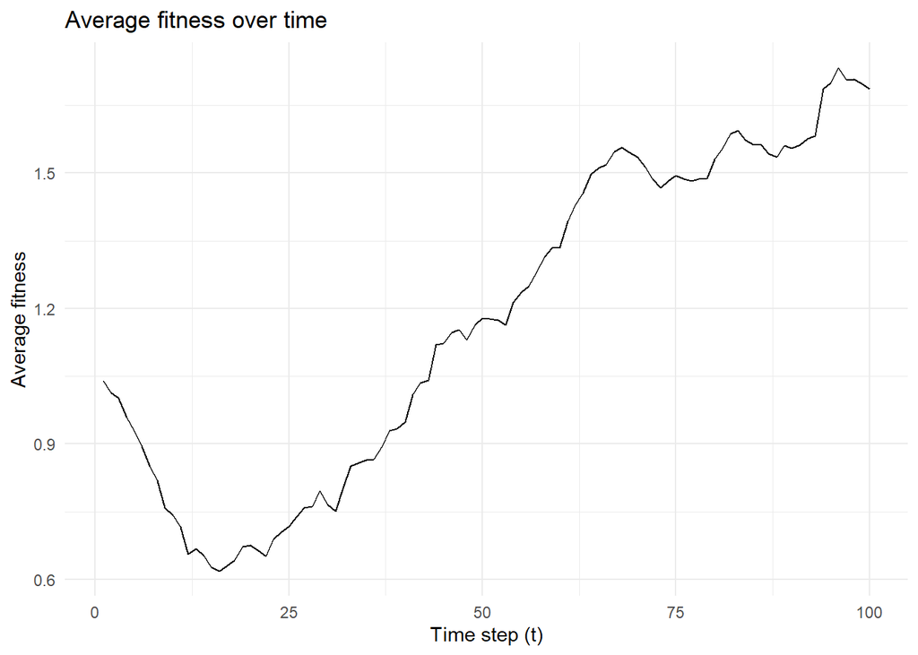

Figure 1: Average fitness across 100 rounds.

```r
df <- data.frame(
  t            = seq_along(results$avg_fitness_series),
  avg_fitness  = results$avg_fitness_series
)

ggplot(df, aes(t, avg_fitness)) +
  geom_line() +
  labs(
    x = "Time step (t)",
    y = "Average fitness",
    title = "Average fitness over time"
  ) +
  theme_minimal()
```

We observe that the average fitness drops significantly in the early stages — likely due to the dominance of defecting strategies which undermine mutual cooperation. However, after around 25 time steps, the population starts to recover as more cooperative strategies re-emerge and gain traction.

To see which strategies dominate at the end of the simulation, we inspect the final state of the world:

```r
summarise_strategies(results$final_world,10)
```

```
# A tibble: 10 × 3
   strat_id n_agents mean_fitness
   <chr>       <int>        <dbl>
 1 10001          66        1.90
 2 11001           2        1.87
 3 10011          12        1.84
 4 11011           1        1.82
 5 11111           1        1.71
 6 11101           5        1.71
 7 00000           2        0.725
 8 00101           1        0.725
 9 10100           2        0.652
10 01001           1        0.503
```

From the results, we see that two of the top-performing strategies are **Grim Trigger** and **Tit-for-Tat**. These are well-known for promoting conditional cooperation and punishing defection. Their success suggests that the population has found a balance between being cooperative and being cautious.

Interestingly, **Always Defect**, which performed well early on, is no longer among the top strategies — both in terms of fitness and population share. This shows that purely selfish strategies may provide short-term gain but struggle to sustain success when others can adapt.

# Running a Simulation

If you’ve made it this far — well done! You’ve built a full evolutionary agent-based model from scratch. 🎉

In this section, there’s not much theory — just an invitation to explore. Try running the simulation with different parameters, observe how the population evolves, and see how small changes can lead to very different dynamics.

To run large-scale simulations, all you need to do is adjust the helper functions `get_data_replication()` and `get_data_simulations()` in the file `functions_data.R` to extract whatever outputs you are interested in. You can leave the core simulation logic — `run_replications()` and `run_simulation()` — untouched.

The key part that defines what gets simulated is the `simulation` object, particularly the `tbl_parameter` field. This is where you specify the parameters you want to vary. For instance, let’s test the impact of different learning rates (`mu`). Until now, we used `mu = 0.05`, meaning 5 out of 100 agents update their strategy each round. Let’s now compare that with `mu = 0.1` and `mu = 0.2`, and see how this affects the dynamics. We’ll also use a model called `baseline_long` that runs for 750 time steps:

```r
simulation  <- list(
  model = "baseline_long",
  replications = 50,
  tbl_parameter = expand.grid(
    mu = c(0.05, 0.1, 0.2)
  ),
  master_seed  = 42,
  max_cores    = 15
)
```

To run this simulation:

```r
results <- run_simulation(simulation)
```

Since this is computationally intensive, we’ll load precomputed results:

```r
results <- readRDS("data/week04_results.rds")
```

Let’s examine how average fitness evolves over time under different mu values:

**Show R Code (Fitness plot)**

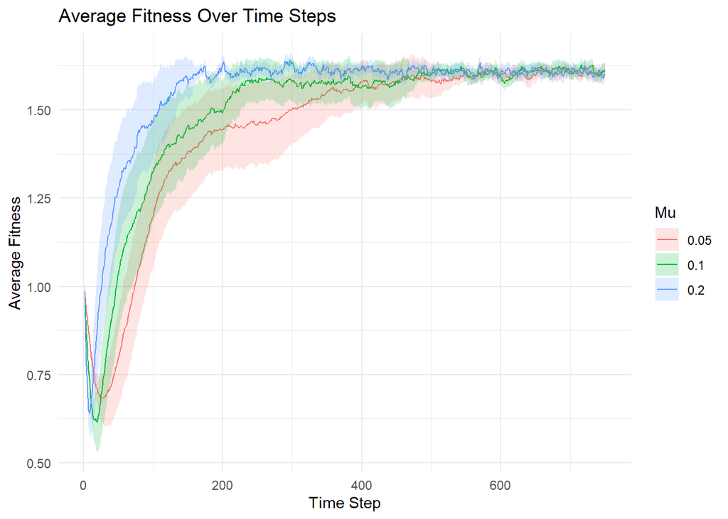

Figure 2: Average fitness across 750 steps for different mu-values and 50 replications each.

```r
ggplot(results$df_fitness %>%
  mutate(
    ci_lower = mean_fitness - 1.96 * (sd_fitness / sqrt(simulation$replications)),
    ci_upper = mean_fitness + 1.96 * (sd_fitness / sqrt(simulation$replications))
  ), aes(x = step, y = mean_fitness, color = factor(mu), fill = factor(mu))) +
  geom_line() +
  geom_ribbon(aes(ymin = ci_lower, ymax = ci_upper), alpha = 0.2, color = NA) +
  labs(
    title = "Average Fitness Over Time Steps",
    x = "Time Step",
    y = "Average Fitness",
    color = "Mu",
    fill = "Mu"
  ) +
  theme_minimal()
```

What we observe is quite insightful: across all values of `mu`, the system initially experiences a decline in average fitness — likely caused by the early collapse of cooperation as defectors exploit cooperators. This is followed by a steady recovery phase. Notably, the **rate of recovery is strongly influenced by the value of `mu`**:

- With `mu = 0.2`, the population reaches a high and stable average fitness by around step 200.
- With `mu = 0.05`, it takes nearly 500 steps to achieve a comparable level.

Higher values of `mu` promote **faster adaptation**, allowing the population to converge more quickly on high-performing strategies. From a practical perspective, this can significantly reduce computational demands: if convergence happens in 200 steps instead of 500, simulations run much faster and consume fewer resources. However, faster learning also comes with a trade-off: **higher volatility**. Too much strategic change may prevent the system from stabilizing, as new strategies are constantly being introduced and tested.

A useful trick to balance **exploration and convergence** is to implement a **decaying learning rate** — starting with a high `mu` to encourage rapid adaptation early on, and then gradually lowering it to allow the system to stabilize as it approaches equilibrium.

Now lets turn to the question what strategies dominate at the end? Let’s take a look:

```r
results$df_top10 |>
  filter(step == 750) |>
  group_by(mu) %>%                         # one group = one μ value
  slice_max(fitness_mean, n = 3,           # keep the 3 best strategies
            with_ties = FALSE) %>%
  ungroup()
```

```
# A tibble: 9 × 8
   step strat_id n_agents_mean n_agents_sd fitness_mean fitness_sd model      mu
  <int> <chr>            <dbl>       <dbl>        <dbl>      <dbl> <chr>   <dbl>
1   750 10001            73.2        11.7          1.87     0.101  baseli…  0.05
2   750 11001             4.61        3.38         1.81     0.0868 baseli…  0.05
3   750 10011             2.74        1.81         1.81     0.0440 baseli…  0.05
4   750 10001            72.9        12.8          1.87     0.0849 baseli…  0.1
5   750 11001             4.44        6.18         1.82     0.0678 baseli…  0.1
6   750 10011             2.44        2.42         1.80     0.0431 baseli…  0.1
7   750 10001            74.6         5.16         1.88     0.0399 baseli…  0.2
8   750 11001             4.39        3.30         1.82     0.0547 baseli…  0.2
9   750 10011             2.74        1.96         1.80     0.0438 baseli…  0.2
```

Surprisingly—or perhaps not—the most successful strategy across all `mu` values is *Grim Trigger*, a well-known cooperative strategy from game theory. In contrast, *Always Defect*, which initially thrives, no longer performs well by the end of the simulation. But this raises an interesting question: **why doesn’t everyone eventually adopt** *Grim Trigger*, especially when so many other strategies perform worse?

This puzzle also helps explain **why the average fitness plateaus around 1.6**, rather than approaching the theoretical maximum of 2 (which would indicate full cooperation). The answer lies in the structure of `update_agents()` and the value of `mu_rnd = 0.2`. With 100 agents, `mu = 0.05`, and `mu_rnd = 0.2`, we expect about **1 agent per round** to adopt a completely random strategy. But why do we end up with 74% cooperative strategies and not 99%?

**Note**

Try to discover (some of) the answers yourself!

Here’s the catch: since changers are selected **randomly**, there’s always a non-zero probability that a highly successful agent — like one using Grim Trigger — will be replaced with a random strategy. This **constant shuffling** prevents the population from fully converging on the optimal strategy, even when it dominates in performance.

To better understand the logic, let’s walk through a simplified scenario where we assume:

- Selection pressure is extremely strong (`w → ∞`)
- Grim Trigger is always the best strategy
- The system updates 5 agents per round (i.e., `mu = 0.05` with 100 agents) and 20% of changers mutate randomly (`mu_rnd = 0.2`), so 1 mutation and 4 imitation updates per round.

Now suppose:

#### Case 1: 40% of agents use Grim Trigger

- On average, 2 Grim Trigger agents and 3 others are selected to change
- 1 of the 5 is randomly mutated
- The remaining 4 imitate the fittest strategy (Grim Trigger)
- Even if the random mutation hits a Grim Trigger agent, the 3 non-GT imitators will convert to Grim Trigger
- **Result:** the share of Grim Trigger increases

#### Case 2: 80% of agents use Grim Trigger

- Now, 4 out of 5 selected changers are Grim Trigger agents
- 1 of them may mutate into a random strategy
- The other 4 either stay the same or copy Grim Trigger again
- The total share of Grim Trigger remains stable or slightly decreases

If you reduce the value of `mu_rnd`, fewer agents will adopt random strategies, and more will imitate high-performing ones. For example, running the model with `mu = 0.1` and `mu_rnd = 0.1` yields a much higher share of Grim Trigger (around 87%) and a correspondingly higher average fitness — closer to 1.8.

# 🧩 Conclusion

In this chapter, we built a fully functional **evolutionary agent-based model** that captures the dynamics of cooperation, defection, learning, and mutation.

# 🏋 Pre-Class Assignment

Before the next session, take some time to engage with the model hands-on. The following exercises will help you consolidate what you’ve learned and begin thinking critically about the dynamics of agent-based models.

**Note**

You can [download the complete code here](https://github.com/SGrehl/SGrehl.github.io/tree/main/data/abm-pd).

1. **[Easy]**  
   Understand why 00000 and 00001 represent the same strategies (tip: in consequence, not in theory).
2. **[Easy]**  
   Play around with the model. Make some changes by either introducing another model (by adding it to `functions_model.R`) or by changing `simulation` especially `tbl_parameter`. Try to visualize your results and tell us about it!
3. **[Medium]**  
   *Conceptual only — no coding required!* Think of some possible changes you could make to `update_agents()` that would still be meaningful but change the evolutionary dynamics. Example: Could you let `mu_rnd` be very small, but still impactful?
4. **[Hard]**  
   *Now try coding it!*  
   Pick one of the conceptual alterations from the previous exercise and implement it in the actual `update_agents()` function. Test how it affects long-term cooperation, equilibrium stability, or average fitness. Bonus points if you document your results in a nice graph!

# 🚀 Link to In-Class Material

# ⚙️ Some Advanced Stuff

In the downloadable code, I’ve added a few key **optimizations** to make the simulation faster and more efficient. The most important of these is the introduction of a **transition matrix**, which replaces the need to manually track each agent’s full interaction history during repeated games.

The transition matrix is generated using the following function:

```r
get_transition_matrix <- function(memory) {
  base_hist <- c("DD", "CD", "DC", "CC")

  # we start only with the very first decision
  decision_points <- "first"

  histories       <- base_hist

  if (memory == 0) {
    return( matrix(rep(1,4),ncol=4))
  }

  if (memory > 0) {
    for (i in seq_len(memory)) {
      decision_points <- c(decision_points, histories)
      histories       <- as.vector(outer(histories, base_hist, paste0))
    }
  }

  n_state  <- length(decision_points)
  idx_of   <- setNames(seq_len(n_state), decision_points)   # label → row number

  trans_mat <- matrix(
    integer(n_state * 4L),          # rows = states, cols = outcomes 1…4
    nrow = n_state, ncol = 4L,
    dimnames = list(decision_points, NULL)
  )

  keep_last <- function(s) {        # keep last <memory> rounds (each is 2 chars)
    keep <- 2L * memory
    if (keep == 0L || nchar(s) <= keep) s else
      substr(s, nchar(s) - keep + 1L, nchar(s))
  }

  for (s in seq_len(n_state)) {
    hist_str <- decision_points[s]
    for (o in 0:3) {
      next_str <- if (hist_str == "first") {
        base_hist[o + 1L]
      } else {
        keep_last(paste0(hist_str, base_hist[o + 1L]))
      }
      trans_mat[s, o + 1L] <- idx_of[[next_str]]
    }
  }

  colnames(trans_mat) <- base_hist

  trans_mat                      # integer matrix, indices start at 1
}
```

We call this function in `init_world()` and store the resulting matrix in `world$trans_mat`.

Let’s take a look at what this matrix looks like for `memory = 1`:

```r
get_transition_matrix(memory = 1)
```

```
      DD CD DC CC
first  2  3  4  5
DD     2  3  4  5
CD     2  3  4  5
DC     2  3  4  5
CC     2  3  4  5
```

This 5×4 transition matrix (for memory = 1) replaces the need for explicit history tracking in repeated interactions. Here’s how to read it:

- Each **row** represents a possible state based on past history (e.g. `"first"`, `"DD"`, `"CD"`, etc.).
- Each **column** represents one of the four possible round outcomes (`DD`, `CD`, `DC`, `CC`).
- Each **cell** tells us which state (i.e. which row) an agent will move to **after** observing that outcome.

This effectively encodes the full state-transition logic of repeated interactions.

In our optimized `run_step_fast()` function, we no longer need to store or update complex history strings. Instead, we simply track each agent’s **current state index**, which directly maps to both:

1. The action the agent should take (via their strategy vector), and
2. The next state they will move to, based on the current round’s outcome.

Let’s see this in action:

- Assume an agent is using **Grim Trigger**, with a strategy vector: `strat_i = c(1, 0, 0, 0, 1)` .
- The agent starts in the `"first"` state → this corresponds to `state_i = 1` or row 1.
- So the agent plays `strat_i[state_i] = strat_i[1] = 1` (cooperate).

Now, suppose both agents cooperate. This outcome is `"CC"` and corresponds to column 4. Looking up `transition_matrix[1, 4]`, we find the next state (in this case, state 5). Next round, the agent will: Play `strat_i[5] = 1` (still cooperating),

This setup is **computationally efficient** because:

- Each agent only needs to store one integer (`state`), not an entire history,
- Strategy lookup is a simple vector access,
- State transitions are handled via a precomputed matrix.

### Rcpp

While the transition matrix version of `run_step()` is already much faster than our original implementation, it still isn’t fast enough for **large-scale simulations** — especially when we scale up to many agents, long games, or multiple replications.

This is where one of R’s hidden superpowers comes in: **seamless integration with C++** via the **Rcpp** package. C++ is a compiled language and is **exceptionally fast**, particularly when dealing with **nested loops** and **low-level memory operations** — exactly what we need for our simulation.

To speed things up even further, I asked ChatGPT nicely: *“Could you translate my `run_step()` function into efficient C++ code for use with R?”*. And it did just that. Again it is your responsibility to check these outputs are correct or not.

I saved the resulting code in an external file called `run_step_fast.cpp`. To use it in R, you just load it with:

```r
library(Rcpp)
Rcpp::sourceCpp("run_step_fast.cpp")
```

This loads the compiled C++ function directly into your R session — no additional setup required. From there, you can call it just like a regular R function (i named it `run_step_fast_cpp()`), but somewhat 1000x faster than the original function.

## References

Axelrod, Robert. 1980. “Effective Choice in the Prisoner’s Dilemma.” *Journal of Conflict Resolution* 24 (1): 3–25. https://doi.org/10.1177/002200278002400301.

## Copyright

Copyright Sascha Grehl, 2025. All Rights Reserved